# Clase 31.07

Cuando un dispositivo (como una computadora) quiere comunicarse con otro dentro de la misma red, necesita saber la dirección MAC del destino. Si solo conoce la dirección IP, usa ARP para descubrir la MAC correspondiente.

- El dispositivo envía una solicitud ARP (ARP Request) a toda la red: "¿Quién tiene la IP 192.168.1.10? Responde con tu MAC."
- El dispositivo con esa IP responde con su dirección MAC.
- El solicitante guarda esa asociación IP ↔ MAC en su tabla ARP, una caché temporal.

En algun momento tenemos la necesidad que direccion fisica tiene una direccion ip. Entonces lo que hace el protocolo cuando alguien tiene la necesidad de hacer eso. Lo manda al brodcast del canal.

Y quien se identifique, sabe quien tiene ese dato . La persona o la entidad responderia que tiene eso.

La respuesta es directa la pregunta en brodcast. En cache se almacena las respuestas del ARP para no andar repitiendo lo mismo.

[figure not shown]

Mira asi le respondio el router

el **sudo arp -va enlistar la cache**

**arp -v es verbose** **-a formateo address ip***

**-d borrar del registro** esto lo hacemos con sudo arp para eliminar la ip de la cache , el automaticamente llama coon arp

# Clase 05.08

## Capa de Red

Lo que tratamos de hacer es a diferencia de la capa de enlace, es no hacer cada uno de los saltos, sino que hay que hacer varios saltos para llevar paquetes

## Routers

### Forwading

Hacer reeenvio, accion de transferrior paquete en un enlace de netrada y un enlace de salida.

### Routing

Proceso de rutas que los paquetes, y el se encarga de llenar las tablas que se consultan para saber en que direccion llegara el paquete

Entonces uno revisa la tabla y el otro la llena.

## Sevicio Conecttion oriented y Coneection Less

### Coneccion Less

Es el que gano ,estandar debido a que la filosofia de extremo a extremo, las redes en si que los datos no son confiables, entonces que sepamos que uno de cada tanto se va a perder. Si la red no es confiable, el punto A al punto B entre saltos pondre la direccion completa de destino y se recalcula la ruta, y cada host maneja errores. Esta basicamente tipo brodcast el servicio y de ahi viene ip.

### Conection Oriented

No se recalcula la ruta, sino que se reserva la ruta entera. Y entonces se reservan variables y rutas en donde va a correr. Osea la ruta ya se reservo. Se gano una conexion, va a llegar bien los paquetes. Por eso se caia el internet al usar el telefono a la vez

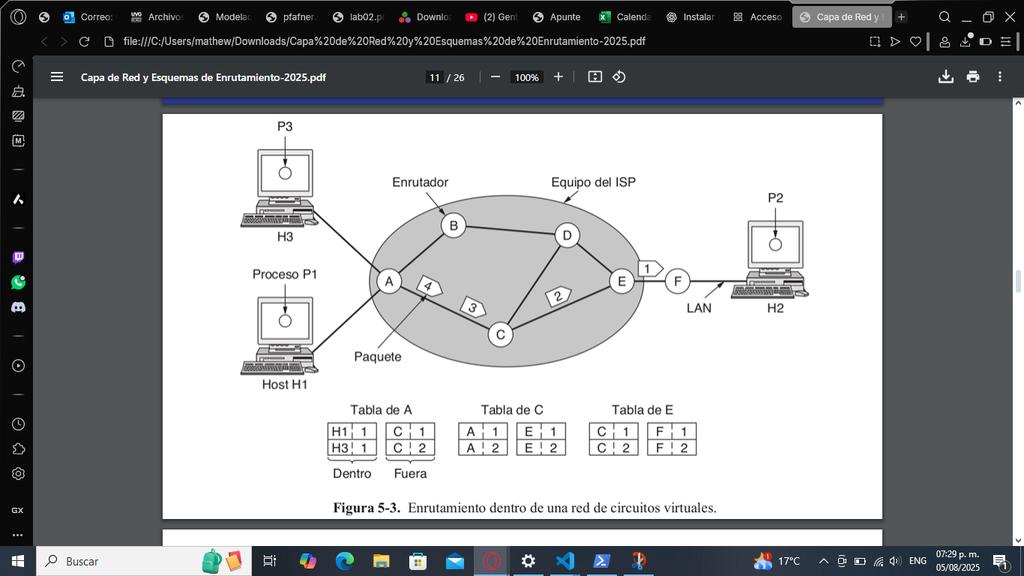

Aqui puedes ver que ya se reservo esos saltos y nadie mas los puede usar, de aqui viene UDP

### Algoritmos de Enrutamiento

-Tienen que ser simple

- Robusto ante fallos y nuevos nodos
- Estable o que converge osea que la tabla de enrutamiento converga a una definitiva
- Justo que todos puedan usar la red bien

Un ejemplo es aqui

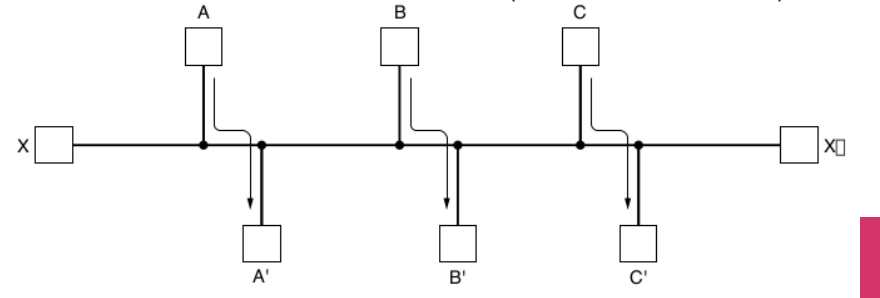

El problema es que X y x' quieren comunicarse entre si. Entonces lo que podemos hacer para balancearlo es decirle a A y B que no compartan comunicacion, y entonces usar el canal, pero en esta distribucion sacrificas eficiencia.

### Bellman

Hay maneras de optimizar los saltos entre cada enlace, lo que podemos usar son algoritmos de optimizacion como e Bellman.

Lo que queremos hacer es encontrar optimizas, lo que dice es

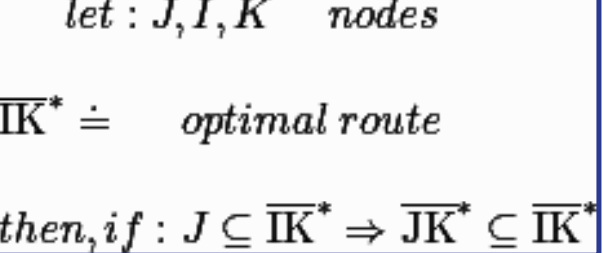

Hay ciertos nodos en un grafo , pero hay una ruta con minima distancia. Si resulta que hay otro nodo J , por consiguiente, ese nodo es parte de la ruta optima si J es optimo.

Nos dice que la subruta , tambien pertenece a la ruta optima. Esto para N nodos aplica.

### Djiskstra

Resuelve la ruta optima, lo que hace es que vamos a ir iterativvamente resolviendo el grafo, no solo resuleto la ruta de A a B , sino todas las rutas de A hacia todos los destinos y encontrar la que tenga el menor de los pesos.

El problema es que la red no es estatica sino dinamica. Y djisktra depende de que si sea estatico.

## Flooding

El problema de este es que por brodcast mandamos todo

[figure not shown]

Osea que hacemos propagacion a todos los vecinos y estos a sus vecinos

## Algirmots Dinamicos

### Disntacia Vector Routing

[figure not shown]

EL enrutador va a recibir de todos la informacion de la tabla, pero cada PC pedira al router la tabla que debemos de usar.

### Link state routing

Para llegar a la convergencia de la tabla, el problema es que cuando alguien se desconectaba en el anterior, entonces para darse cuenta que estaba muerto pasa muchisimo.

Cada router descubre su vecindario (a quién está conectado y el costo de los enlaces).

Envía esa información a todos los routers (mediante mensajes llamados Link State Advertisements, LSAs).

Todos los routers construyen un mapa completo de la red.

Cada router calcula la mejor ruta a cada destino usando Dijkstra.

# Clase 0708

Esta fue de un repaso rapido de la anterior solo recordar que

- Paquetes que se envian en la red

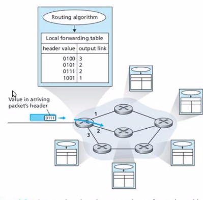

- Paquetes que se envian en la red

## Proyecto 1

[figure not shown]

[Link de la Pagina](https://modelcontextprotocol.io/specification/2025-06-18/basic#schema)

Vamos a hacer un MCP server , en donde pueda usar los LLMS para poder nutrirse y saber que hacer. EL objetivo es un chat donde le puedas hacer varias preguntas , esto se hace con un protocolo de RCP y json usando un server MCP.

La parte de probar remoto,no vamos a probar, es que pasaremos el .py del server, lo que hace MCP hace las llamadas y toma el control del server. Pasamos el codgo dela gente porque nos gastaremos los credtos de los demas.